# Reshape Metadata

The meta data is given on a per-sample basis. For some metrics, particularly the *changes in a given metric* it is much more intuitive to work in a per-participant framework. In this document, we rearrange the data, and add some features.

## Settup

### Libraries

```r
tellme <- function(name){message("Package ", name, " version: ", packageVersion("tidyr"))}
library(tidyr); tellme("tidyr")
suppressPackageStartupMessages(library(dplyr)); tellme("dplyr")
```

```r
library(ggplot2); tellme("ggplot2")
```

Direct output.

Output will be saved to: `../output`

### Read metadata

Read data.

```r
meta = read.delim("../../input/meta/ANIGMA-metadata.txt") %>%
  select(PARTICIPANT.ID, LOCATION, TIMEPOINT, AGE, SUBTYPE, BMI,
         STAI_Y1, STAI_Y2, STAI_TOTAL, PSS, DAYS_TREAT, Weight_kg,
         DUR_ILLNESS_YRS)
dim(meta)
```

```
## [1] 352  13
```

This meta data has `352` rows and `13` columns.

### Remove/modify individual data.

Note: 469017 and 469019 are the outliers (same as before!) who lost weight during their stay, this was attributed to medication they had been taking ahead of their stay that lead to inflated weight values on arrival. So the T1 weight (and by extention bmi) is not a valid measure here.

```r
meta[meta$PARTICIPANT.ID=="469017", "BMI"] = NA
meta[meta$PARTICIPANT.ID=="469019", "BMI"] = NA
```

```r
meta[meta$PARTICIPANT.ID=="469021" & meta$TIMEPOINT=="T2", "PSS"] = NA
meta[meta$PARTICIPANT.ID=="469101" & meta$TIMEPOINT=="T1", "PSS"] = NA
```

After this modification, this meta data has `352` rows and `13` columns.

## Arrange data by participant

```r
# Pull out the constants,
diffs = meta %>% filter(TIMEPOINT=="T1") %>%
  mutate(T1.severity = 18.5 - BMI) %>%
  select(PARTICIPANT.ID, LOCATION, AGE, SUBTYPE, T1.severity, DAYS_TREAT, DUR_ILLNESS_YRS)

# Loop through all the things that have a T2-T1 difference.
diffables = c("STAI_Y1", "STAI_Y2", "STAI_TOTAL", "PSS", "BMI", "Weight_kg")
for (feature in diffables){
  t1t2diff = meta %>%
    select(PARTICIPANT.ID, all_of(feature), TIMEPOINT) %>%
    pivot_wider(id_cols = PARTICIPANT.ID, names_from = TIMEPOINT, values_from = all_of(feature)) %>%
    select(PARTICIPANT.ID, T1, T2) %>%
    mutate(diff = T2 - T1) %>%
      rename_with( function(name){
          name = ifelse(name=="diff", paste0(feature, ".diff"), name)
          name = ifelse(name=="T1", paste0(feature, ".T1"), name)
          name = ifelse(name=="T2", paste0(feature, ".T2"), name)
          return(name)
      } )
  # %>%
  #   select(PARTICIPANT.ID, all_of(feature))
  diffs = merge(diffs, t1t2diff, by="PARTICIPANT.ID", all=T)
}

dim(diffs)
```

```
## [1] 254  25
```

### Export Reshaped data

Export the wide form data.

```r
fileName = file.path(outdir, "ANIGMA-metadata_by_AN_participant.txt")
write.table(diffs, file=fileName, sep="\t", quote=F, row.names = F)
```

The reshaped data was saved to: `../output/ANIGMA-metadata_by_AN_participant.txt`.

We won’t save the HC data to a file; just show the code and the size summary.

The HC equivalent data frame:

```r
HC = meta %>% filter(TIMEPOINT=="HC") %>%
  select(PARTICIPANT.ID, LOCATION, AGE, SUBTYPE, STAI_Y1, STAI_Y2, STAI_TOTAL, PSS, BMI, Weight_kg)
```

This subset of the data has `136` rows and `10` columns.

## Visualize broad view correlations

Understand which values within the metadata are correlated. Make sure you understand how these things are related in reality and mathematically.

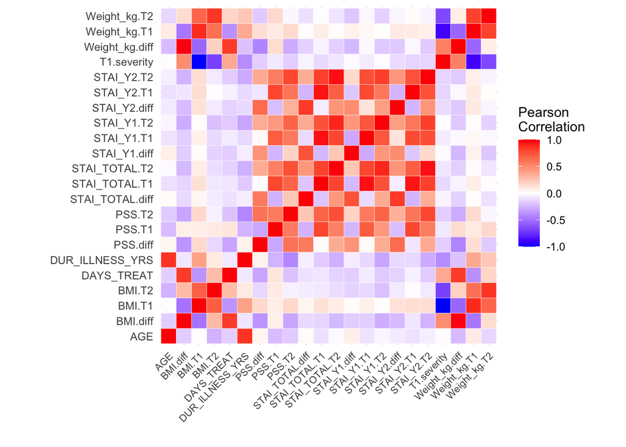

```r
# much of this is taken from
# http://www.sthda.com/english/wiki/ggplot2-quick-correlation-matrix-heatmap-r-software-and-data-visualization

#functions
tidyMelt <- function(cormat, values_name="values"){
    cormat.new = cormat %>% data.frame()
    cormat.new$var1 = row.names(cormat.new)
    melted_cormat = cormat.new %>% pivot_longer(cols=-var1, names_to = "var2", values_to = values_name)
    return(melted_cormat)
}

make_heatmap_1 <- function(cor.co2){
    ggplot(data = cor.co2, aes(x=var1, y=var2, fill=cor)) +
        geom_tile(color = "white")+
        scale_fill_gradient2(low = "blue", high = "red", mid = "white",
                             midpoint = 0, limit = c(-1,1), space = "Lab",
                             name="Pearson\nCorrelation",
                             na.value = gray(.9)) +
        theme_minimal()+ # minimal theme
        xlab("") +
        ylab("") +
        theme(axis.text.x = element_text(angle = 45, vjust = 1,
                                         size = 8, hjust = 1)) +
        coord_fixed()
}

df = diffs %>% select(-PARTICIPANT.ID, -LOCATION, -SUBTYPE)
cor.co = cor(df, use="pairwise.complete.obs", method = "pearson")
cor.co2 = tidyMelt(cor.co, values_name="cor")

make_heatmap_1(cor.co2)
```

Use only the upper triangle, and order features in a sensible way.

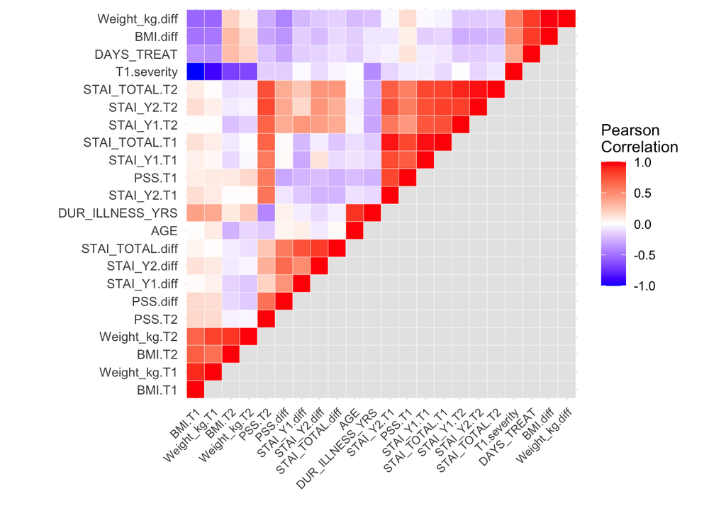

```r
# actions

# Reorder the correlation matrix
cormat <- reorder_cormat(cor.co)
# upper_tri <- get_upper_tri(cormat)
triangle1 = get_upper_tri(cormat)
# Melt the correlation matrix
melted_cormat = tidyMelt(triangle1, values_name="cor")
# order levels to match triangle
melted_cormat$var1 = factor(melted_cormat$var1, levels=row.names(triangle1))
melted_cormat$var2 = factor(melted_cormat$var2, levels=row.names(triangle1))

# Create a ggheatmap
make_heatmap_1(melted_cormat)
```

manually set the order.

```r
manual.order = c('BMI.T1', 'Weight_kg.T1', 'BMI.T2', 'Weight_kg.T2',
                 'T1.severity', 'DAYS_TREAT', 'BMI.diff', 'Weight_kg.diff',
                 'AGE', 'DUR_ILLNESS_YRS',
                 'PSS.diff', 'STAI_Y1.diff', 'STAI_Y2.diff', 'STAI_TOTAL.diff',
                 'PSS.T2',
                 'STAI_Y2.T1', 'PSS.T1', 'STAI_Y1.T1', 'STAI_TOTAL.T1', 'STAI_Y1.T2', 'STAI_Y2.T2', 'STAI_TOTAL.T2')
```

Replot with manual order.

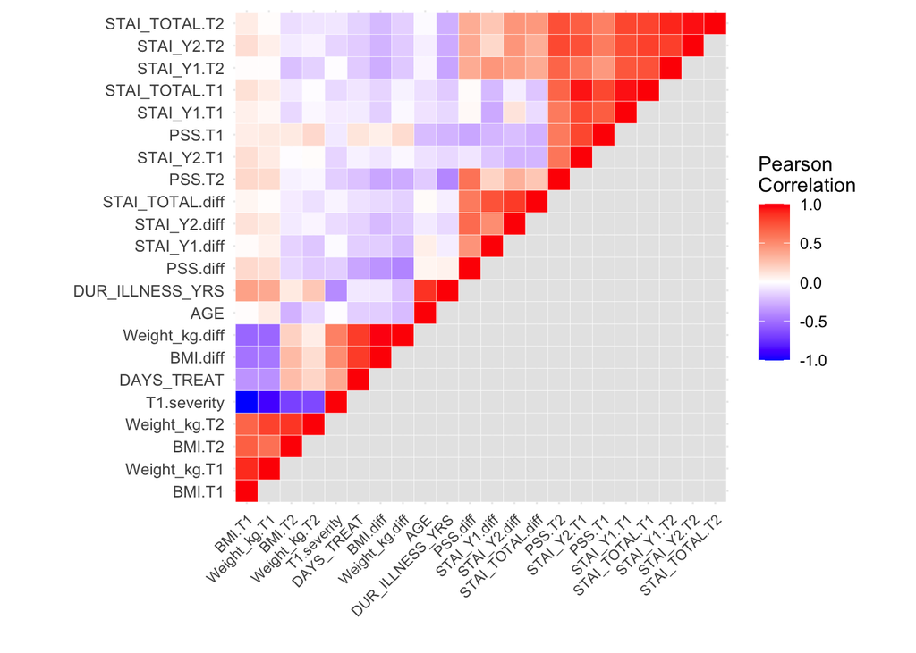

```r
# Reorder the correlation matrix
cormat <- cor.co[manual.order, manual.order]

# upper_tri <- get_upper_tri(cormat)
triangle1 = get_upper_tri(cormat)
# Melt the correlation matrix
melted_cormat = tidyMelt(triangle1, values_name="cor")
# order levels to match manual order
melted_cormat$var1 = factor(melted_cormat$var1, levels=row.names(triangle1))
melted_cormat$var2 = factor(melted_cormat$var2, levels=row.names(triangle1))

# Create a ggheatmap
make_heatmap_1(melted_cormat)
```

Now lets get some p-values

```r
feats = colnames(df)

cors = matrix(data=NA, nrow=length(feats), ncol=length(feats), dimnames = list(feats, feats))
pvals = cors
cors.sig = cors

for (i in feats){
    for (j in feats){
        if ( i != j ){
            res = cor.test(df[,i], df[,j], method="pearson")
            cors[i,j] = res$estimate
            pvals[i,j] = res$p.value
            if (res$p.value < 0.01){
                cors.sig[i,j] = res$estimate
            }
        }
    }
}
```

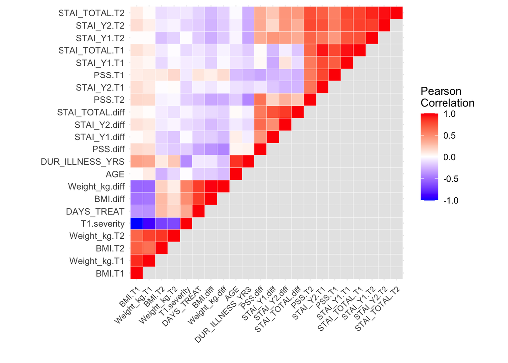

```r
reshapeMatrixToPlot <- function(correlationMatrix){
    # Reorder the correlation matrix
    cormat <- correlationMatrix[manual.order, manual.order]

    # only one triangle
    triangle1 = get_upper_tri(cormat)

    # Melt the correlation matrix
    melted_cormat = tidyMelt(triangle1, values_name="cor")

    # order levels to match triangle order
    melted_cormat$var1 = factor(melted_cormat$var1, levels=row.names(triangle1))
    melted_cormat$var2 = factor(melted_cormat$var2, levels=row.names(triangle1))

    return(melted_cormat)
}

# match most recent plot - show melt and plot method matches
make_heatmap_1(reshapeMatrixToPlot(cor.co))
```

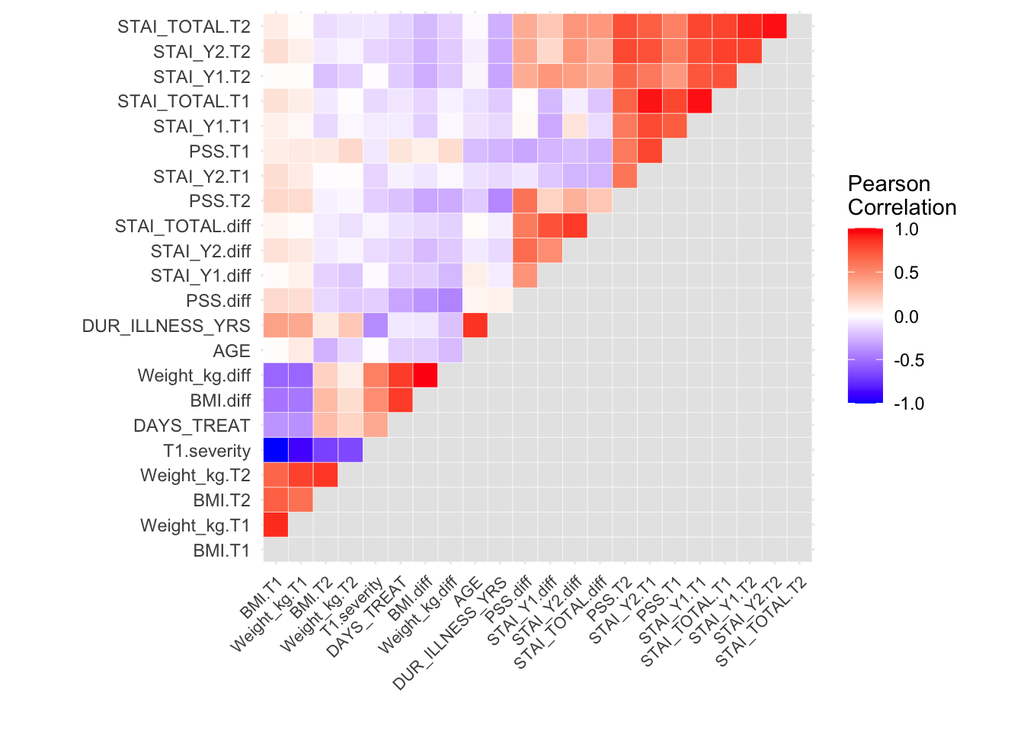

```r
# should also match most recent plot - show input matrix matches
make_heatmap_1(reshapeMatrixToPlot(cors))
```

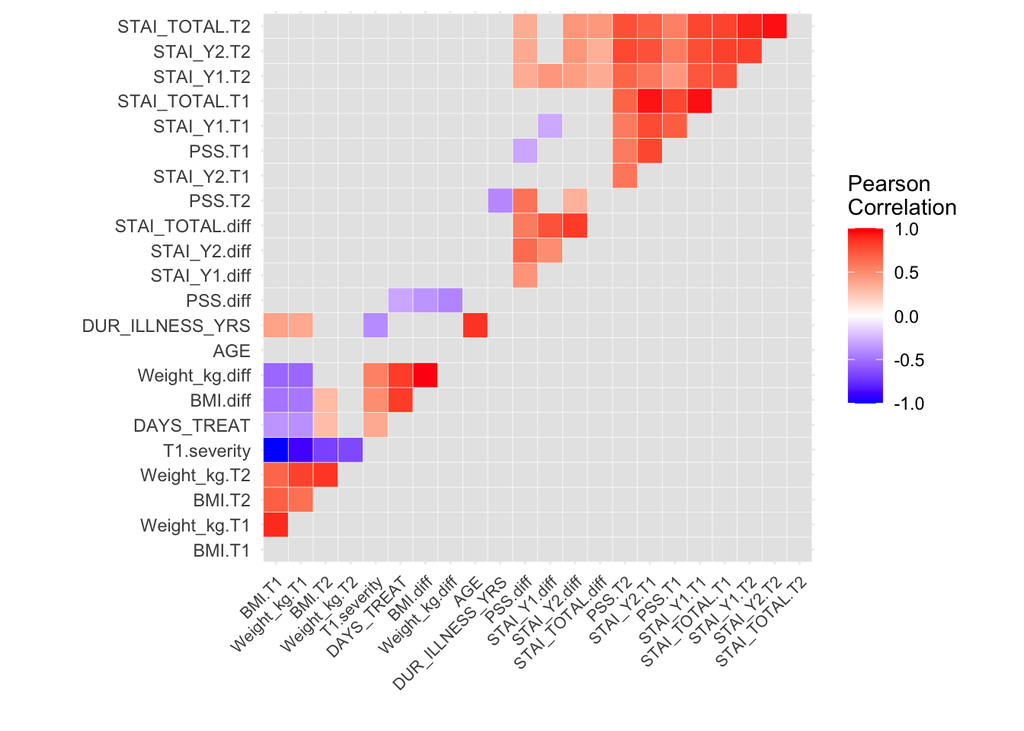

```r
# only sig
make_heatmap_1(reshapeMatrixToPlot(cors.sig))
```

Now lets note what is mathwise related.

```r
# T1 severity is related to BMI at T1 and therefore also related to weight at T1
severity = data.frame(x=c("T1.severity", "T1.severity"),
                      y=c("BMI.T1", "Weight_kg.T1"))

related = data.frame(x=c("STAI_TOTAL", "STAI_TOTAL", "BMI"),
                     y=c("STAI_Y1", "STAI_Y2", "Weight_kg"))
# these are related within a given time point
related1 = data.frame(x=paste(related$x, "T1", sep="."),
                      y=paste(related$y, "T1", sep="."))
related2 = data.frame(x=paste(related$x, "T2", sep="."),
                      y=paste(related$y, "T2", sep="."))

# by extension, the diff of each thing is related to each time point of the other thing
related1.diff = data.frame(x=paste(related$x, "T1", sep="."),
                      y=paste(related$y, "diff", sep="."))
related1.diff.rev = data.frame(x=paste(related$x, "diff", sep="."),
                      y=paste(related$y, "T1", sep="."))
related2.diff = data.frame(x=paste(related$x, "T2", sep="."),
                      y=paste(related$y, "diff", sep="."))
related2.diff.rev = data.frame(x=paste(related$x, "diff", sep="."),
                      y=paste(related$y, "T2", sep="."))

# all diffables have a relationship between their diff and each time point
relatedDiff1 = data.frame(x=paste(diffables, "T1", sep="."),
                         y=paste(diffables, "diff", sep="."))
relatedDiff2 = data.frame(x=paste(diffables, "T2", sep="."),
                         y=paste(diffables, "diff", sep="."))

stack = rbind(related1, related2,
              related1.diff, related1.diff.rev,
              related2.diff, related2.diff.rev,
              relatedDiff1, relatedDiff2,
              severity)

# relatedness goes both ways
reverse.stack = data.frame(x=stack$y, y=stack$x)
stack2 = rbind(stack, reverse.stack)
```

test annotations

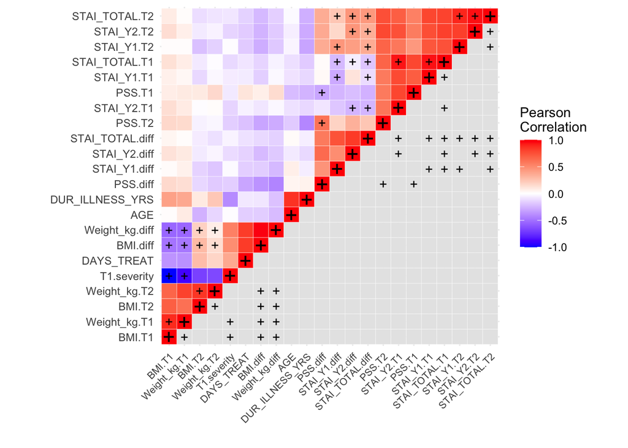

```r
make_heatmap_1(reshapeMatrixToPlot(cor.co)) +
    # mark related features
    annotate(geom="text", x=stack2$x, y=stack2$y, label="+") +
    # identity line gets similar marking, slighly bigger
    annotate(geom="text", x=feats, y=feats, label="+", size=6)
```

### Finalize figure

Show all correlations on the upper triangle but in the lower triangle show only the significant ones.

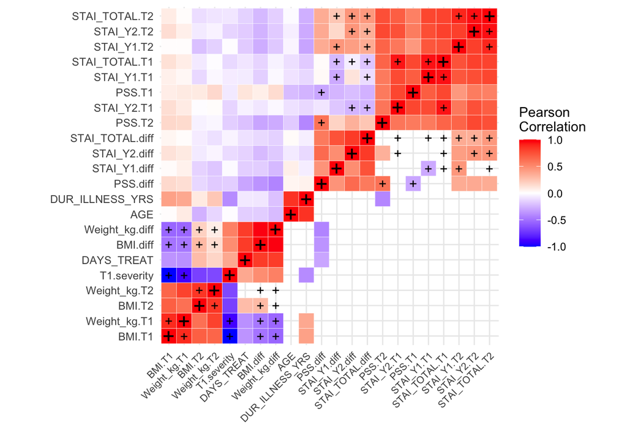

```r
# upper - all correlation values
# Reorder the correlation matrix
cormat <- cor.co[manual.order, manual.order]
# only one triangle
triangle1 = get_upper_tri(cormat)
# Melt the correlation matrix
melted_cormat1 = tidyMelt(triangle1, values_name="cor") %>% filter(!is.na(cor))
# order levels to match triangle order
melted_cormat1$var1 = factor(melted_cormat1$var1, levels=manual.order)
melted_cormat1$var2 = factor(melted_cormat1$var2, levels=manual.order)

# lower - only sig values
cormat <- cors.sig[manual.order, manual.order]
# only one triangle
get_lower_tri2<-function(cormat){
    cormat[upper.tri(cormat)] <- 50
    for (f in feats){
        cormat[f, f] <- 50
    }
    return(cormat)
}
triangle2 = get_lower_tri2(cormat)

# Melt the correlation matrix
melted_cormat2 = tidyMelt(triangle2, values_name="cor") %>% filter(cor != 50)
# order levels to match triangle order
melted_cormat2$var1 = factor(melted_cormat2$var1, levels=manual.order)
melted_cormat2$var2 = factor(melted_cormat2$var2, levels=manual.order)

# merge in melted form
melted_cormat = rbind(melted_cormat1, melted_cormat2)
# order levels to match triangle order
melted_cormat$var1 = factor(melted_cormat$var1, levels=manual.order)
melted_cormat$var2 = factor(melted_cormat$var2, levels=manual.order)

figure = make_heatmap_1(melted_cormat) +
    # mark related features
    annotate(geom="text", x=stack2$x, y=stack2$y, label="+") +
    # identity line gets similar marking, slighly bigger
    annotate(geom="text", x=feats, y=feats, label="+", size=6)
print(figure)
```

Save figure to file.

```r
ggsave(filename = file.path(outdir, "correlations.png"),
       plot = figure)
```

As a function:

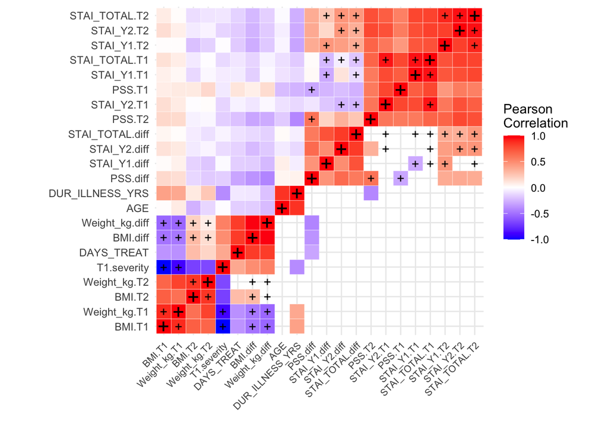

```r
make_heatmap_2 <- function(dataframe, my.order=manual.order){

    cor.co = cor(dataframe, use="pairwise.complete.obs", method = "pearson")

    feats = colnames(dataframe)

    cors = matrix(data=NA, nrow=length(feats),
                  ncol=length(feats),
                  dimnames = list(feats, feats))
    pvals = cors
    cors.sig = cors

    for (i in feats){
        for (j in feats){
            if ( i != j ){
                res = cor.test(dataframe[,i], dataframe[,j], method="pearson")
                pvals[i,j] = res$p.value
                if (res$p.value < 0.01){
                    cors.sig[i,j] = res$estimate
                }
            }
        }
    }



    # upper - all correlation values
# Reorder the correlation matrix
cormat <- cor.co[my.order, my.order]
# only one triangle
triangle1 = get_upper_tri(cormat)
# Melt the correlation matrix
melted_cormat1 = tidyMelt(triangle1, values_name="cor") %>% filter(!is.na(cor))
# order levels to match triangle order
melted_cormat1$var1 = factor(melted_cormat1$var1, levels=my.order)
melted_cormat1$var2 = factor(melted_cormat1$var2, levels=my.order)

# lower - only sig values
cormat <- cors.sig[my.order, my.order]
# only one triangle
get_lower_tri2<-function(cormat){
    cormat[upper.tri(cormat)] <- 50
    for (f in feats){
        cormat[f, f] <- 50
    }
    return(cormat)
}
triangle2 = get_lower_tri2(cormat)

# Melt the correlation matrix
melted_cormat2 = tidyMelt(triangle2, values_name="cor") %>% filter(cor != 50)
# order levels to match triangle order
melted_cormat2$var1 = factor(melted_cormat2$var1, levels=my.order)
melted_cormat2$var2 = factor(melted_cormat2$var2, levels=my.order)

# merge in melted form
melted_cormat = rbind(melted_cormat1, melted_cormat2)
# order levels to match triangle order
melted_cormat$var1 = factor(melted_cormat$var1, levels=my.order)
melted_cormat$var2 = factor(melted_cormat$var2, levels=my.order)

figure = make_heatmap_1(melted_cormat) +
    # mark related features
    annotate(geom="text", x=stack2$x, y=stack2$y, label="+") +
    # identity line gets similar marking, slighly bigger
    annotate(geom="text", x=feats, y=feats, label="+", size=6)
return(figure)
}

fig1 = make_heatmap_2(diffs %>% select(-PARTICIPANT.ID, -LOCATION, -SUBTYPE))
fig1
```

```r
# fig2.acute = make_heatmap_2(diffs %>%
#                           filter(LOCATION == "ACUTE") %>%
#                           select(-PARTICIPANT.ID, -LOCATION, -SUBTYPE))
# fig2.acute
# fig2.ceed = make_heatmap_2(diffs %>%
#                           filter(LOCATION == "CEED") %>%
#                           select(-PARTICIPANT.ID, -LOCATION, -SUBTYPE))
# fig2.ceed
```